# FA 2: Linear Models: Simple Linear Least-Squares Regression

2026-09-15

*Part 1 – Understanding the Dataset*

*A. Identify the Variable*

The predictor variable (X) is **TV advertising expenditure**, while the response variable (Y) is **Sales**.

*B. Describe the Variables*

TV measures the advertising budget spent on television, expressed in thousands of dollars. Sales measures product sales, expressed in thousands of units. The dataset contains information from 200 markets.

*C. Research Question*

Can product sales be predicted from TV advertising expenditure?

```r
# Load data
setwd("~/Linear Model files/FA 2")
advertising <- read.csv("Advertising.csv")

# Inspect data
head(advertising)
```

```
##   X    TV radio newspaper sales
## 1 1 230.1  37.8      69.2  22.1
## 2 2  44.5  39.3      45.1  10.4
## 3 3  17.2  45.9      69.3   9.3
## 4 4 151.5  41.3      58.5  18.5
## 5 5 180.8  10.8      58.4  12.9
## 6 6   8.7  48.9      75.0   7.2
```

```r
dim(advertising)
```

```
## [1] 200   5
```

```r
summary(advertising)
```

```
##        X                TV             radio          newspaper
##  Min.   :  1.00   Min.   :  0.70   Min.   : 0.000   Min.   :  0.30
##  1st Qu.: 50.75   1st Qu.: 74.38   1st Qu.: 9.975   1st Qu.: 12.75
##  Median :100.50   Median :149.75   Median :22.900   Median : 25.75
##  Mean   :100.50   Mean   :147.04   Mean   :23.264   Mean   : 30.55
##  3rd Qu.:150.25   3rd Qu.:218.82   3rd Qu.:36.525   3rd Qu.: 45.10
##  Max.   :200.00   Max.   :296.40   Max.   :49.600   Max.   :114.00
##      sales
##  Min.   : 1.60
##  1st Qu.:10.38
##  Median :12.90
##  Mean   :14.02
##  3rd Qu.:17.40
##  Max.   :27.00
```

*PART 2 – Exploratory Data Analysis*

*A. Scatterplot*

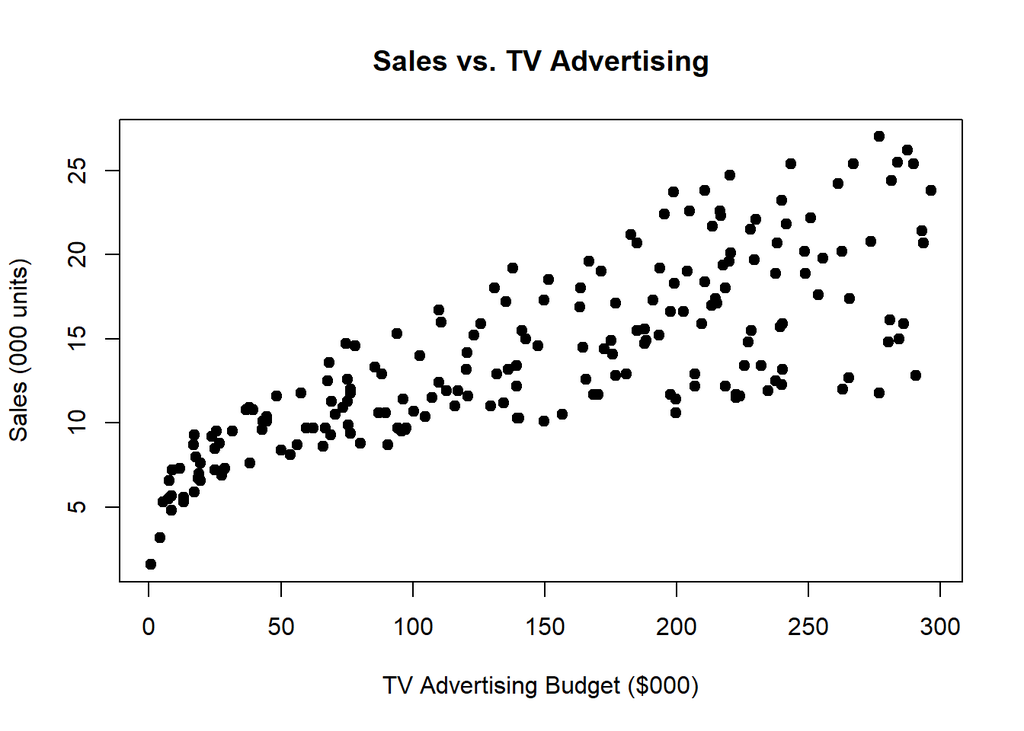

```r
# Scatterplot
plot(advertising$TV,
     advertising$sales,
     main = "Sales vs. TV Advertising",
     xlab = "TV Advertising Budget ($000)",
     ylab = "Sales (000 units)",
     pch = 19)
```

*B. Interpretation of the Scatterplot*

The scatterplot shows a positive relationship between TV advertising expenditure and Sales. As TV advertising expenditure increases, Sales generally tend to increase. The relationship appears to be reasonably strong and approximately linear. Therefore, TV advertising expenditure appears to be potentially useful for predicting Sales.

*PART 3 – Simple Linear Regression Model*

*A. Fit the Model in R*

```r
# Simple linear regression
model <- lm(sales ~ TV, data = advertising)

# Regression results
summary(model)
```

```
##
## Call:
## lm(formula = sales ~ TV, data = advertising)
##
## Residuals:
##     Min      1Q  Median      3Q     Max
## -8.3860 -1.9545 -0.1913  2.0671  7.2124
##
## Coefficients:
##             Estimate Std. Error t value Pr(>|t|)
## (Intercept) 7.032594   0.457843   15.36   <2e-16 ***
## TV          0.047537   0.002691   17.67   <2e-16 ***
## ---
## Signif. codes:  0 '***' 0.001 '**' 0.01 '*' 0.05 '.' 0.1 ' ' 1
##
## Residual standard error: 3.259 on 198 degrees of freedom
## Multiple R-squared:  0.6119, Adjusted R-squared:  0.6099
## F-statistic: 312.1 on 1 and 198 DF,  p-value: < 2.2e-16
```

*B. Report the coefficients*

```r
# Regression coefficients
coef(model)
```

```
## (Intercept)          TV
##  7.03259355  0.04753664
```

*C. Regression Equation*

The fitted regression equation is:

$$\widehat{Sales} = 7.0326 + 0.04754(TV)$$
*D. Interpretation of the Slope*

The slope is approximately 0.04754. Therefore, for every additional $1,000 spent on TV advertising, predicted Sales increase by approximately 0.04754 thousand units, or about 47.54 units, on average.

*PART 4 – Least-Squares and Residual Analysis*

*A. Obtain fitted values and residuals*

```r
# Fitted values
advertising$Predicted_Sales <- fitted(model)

# Residuals
advertising$Residual <- residuals(model)
```

*B. Show the first 10 observations*

```r
head(advertising[, c("TV", "sales", "Predicted_Sales", "Residual")], 10)
```

```
##       TV sales Predicted_Sales   Residual
## 1  230.1  22.1       17.970775  4.1292255
## 2   44.5  10.4        9.147974  1.2520260
## 3   17.2   9.3        7.850224  1.4497762
## 4  151.5  18.5       14.234395  4.2656054
## 5  180.8  12.9       15.627218 -2.7272181
## 6    8.7   7.2        7.446162 -0.2461623
## 7   57.5  11.8        9.765950  2.0340496
## 8  120.2  13.2       12.746498  0.4535023
## 9    8.6   4.8        7.441409 -2.6414087
## 10 199.8  10.6       16.530414 -5.9304143
```

*C. Interpret One Residual*

For the first observation, the TV advertising expenditure is 230.1 thousand dollars and the actual Sales are 22.1 thousand units. The predicted Sales are approximately 17.97 thousand units, giving a residual of approximately 4.13 thousand units. This positive residual means that the actual Sales were approximately 4.13 thousand units higher than the Sales predicted by the regression model.

*Part 5 – Residual Plot*

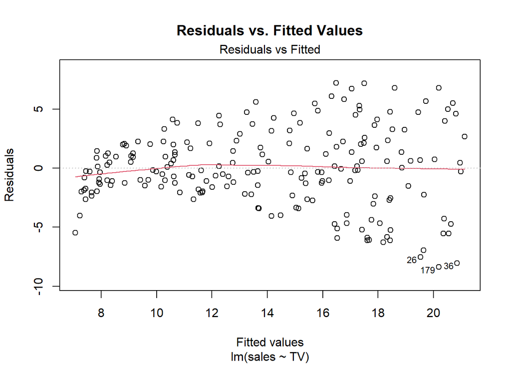

```r
# Residual plot
plot(model,
     which = 1,
     main = "Residuals vs. Fitted Values")
```

*PART 6 – Residual Standard Error*

```r
# Residual standard error
summary(model)$sigma
```

```
## [1] 3.258656
```

*PART 7 – Sums of Squares*

```r
# Sums of squares
y <- advertising$sales
yhat <- fitted(model)

TSS <- sum((y - mean(y))^2)
RSS <- sum((y - yhat)^2)
RegSS <- TSS - RSS

TSS
```

```
## [1] 5417.149
```

```r
RSS
```

```
## [1] 2102.531
```

```r
RegSS
```

```
## [1] 3314.618
```

```r
# Verification
RegSS + RSS
```

```
## [1] 5417.149
```

*Part 8 – Correlation and r²*

```r
# Correlation
r <- cor(advertising$TV,
         advertising$sales)

r
```

```
## [1] 0.7822244
```

```r
# R-squared
r_squared <- r^2

r_squared
```

```
## [1] 0.6118751
```

```r
summary(model)$r.squared
```

```
## [1] 0.6118751
```

*Part 9 – Overall Conclusion*

The scatterplot shows a positive and approximately linear relationship between TV advertising expenditure and Sales. The fitted regression equation is $\widehat{Sales} = 7.0326 + 0.04754(TV)$, which indicates that for every additional $1,000 spent on TV advertising, predicted Sales increase by approximately 0.04754 thousand units on average. The residual standard error is approximately 3.259 thousand units, indicating the typical size of the prediction errors. The correlation coefficient is approximately $r = 0.7822$, showing a strong positive linear association between TV advertising expenditure and Sales. The coefficient of determination is approximately $r^2 = 0.6119$, meaning that about 61.19% of the variation in Sales can be explained by TV advertising expenditure. Overall, TV advertising expenditure appears to be a useful predictor of Sales, although other factors also contribute to the variation in Sales.